# Data Visualization

Christina Minions

2/14/2019

```r
#Load Libraries
library(dplyr)
```

```r
library(tidyr)
library(ggplot2)
library(RColorBrewer)
library(scales)
library(leaflet)
library(DT)
```

## Load in the Data File

```
**Data citation**: Alaska Department of Fish and Game, Division of Commercial Fisheries. 2017. Daily salmon escapement counts from the OceanAK database, Alaska, 1921-2017. Knowledge Network for Biocomplexity. doi:10.5063/F1S46Q6M.
```

```r
esc <- read.csv(url("https://knb.ecoinformatics.org/knb/d1/mn/v2/object/urn%3Auuid%3Af119a05b-bbe7-4aea-93c6-85434dcb1c5e", method = "libcurl"), stringsAsFactors = F)
```

## Reformat the data for Plotting

- Calculate annual escapement by species and region
- Filter for Pacific Salmon (Sockeye, Chinook, Coho, Pink, Chum)

### Methods

1. ‘separate’
2. ‘group_by’
3. ‘summarize’ using the ‘sum’ function

```r
#Separate the Date column into year, month, day
esc_dateChange <- esc %>%
  separate(sampleDate, into = c("year", "month", "day"), sep = "-", remove = F)
```

```r
Groupspecies_YearRegion <- esc_dateChange %>%
  group_by(Species, SASAP.Region, year) %>%
   summarize(Species_sum = sum(DailyCount))
```

### Filter the data for select species

```r
annual_esc <- Groupspecies_YearRegion %>%
  filter(Species %in% c("Chinook", "Sockeye", "Chum", "Coho", "Pink")) %>%
  mutate(year = as.numeric(year))

##If you need to mutate anything after grouping it needs to be done in a sperate line, or it needs to be added into the pipe before grouping happens
```

# General some static plots using ggplot2

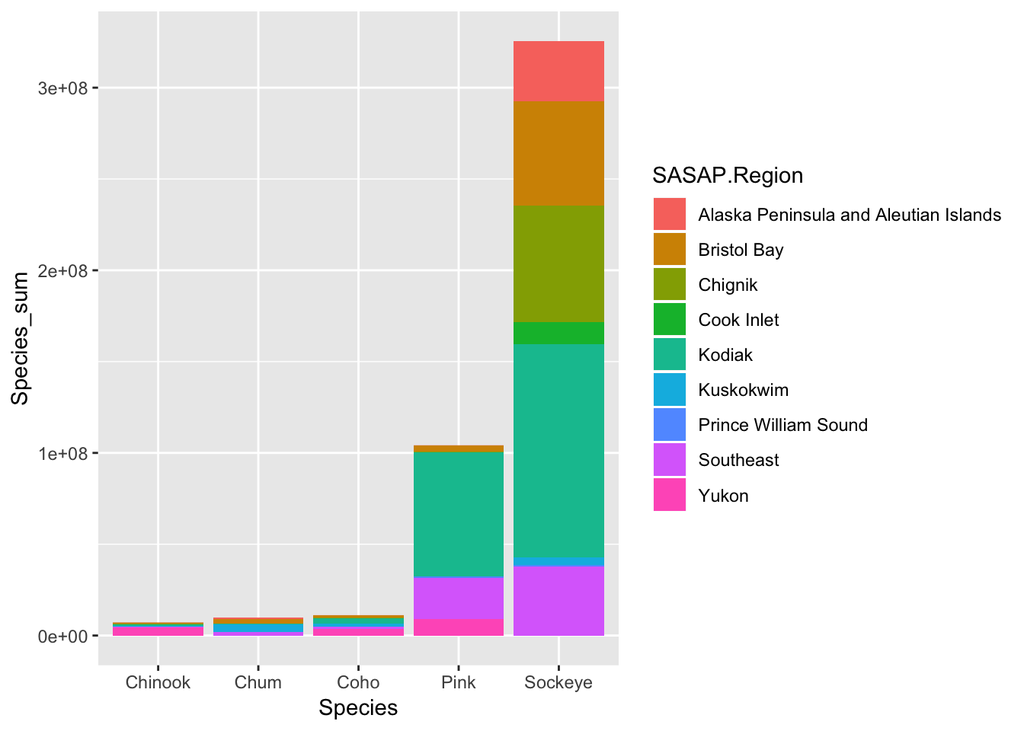

```r
ggplot(annual_esc,aes(x = Species, y = Species_sum, fill = SASAP.Region)) +
  geom_col()
```

[figure not shown]

```r
#ggplot(annual_esc,aes(x = Species, y = Species_mean, fill = SASAP.Region)) +
  #scale_fill_brewer(palette = Paired)
  #geom_col()


##The aes code is way you use to define what data is going to be in the plot. You can either set the mapping with the ggplot function, or within whatever geom function you will be using.

##You can overlap data on the same graph by defining the mapping aes within different geom functions. For example could have a histogram with a line gragh over top
```

### There are a bunch of standard themes already worked into ggplot. This will automatically set theme settings for you, so you don’t have to manual choose every setting.

You can still adjust the theme settings after selecting a pre-set theme

- You can save your theme settings to an object, then you can just add on the theme object that you created to the plot coding (helps keep things in the code a bit more tidy! )

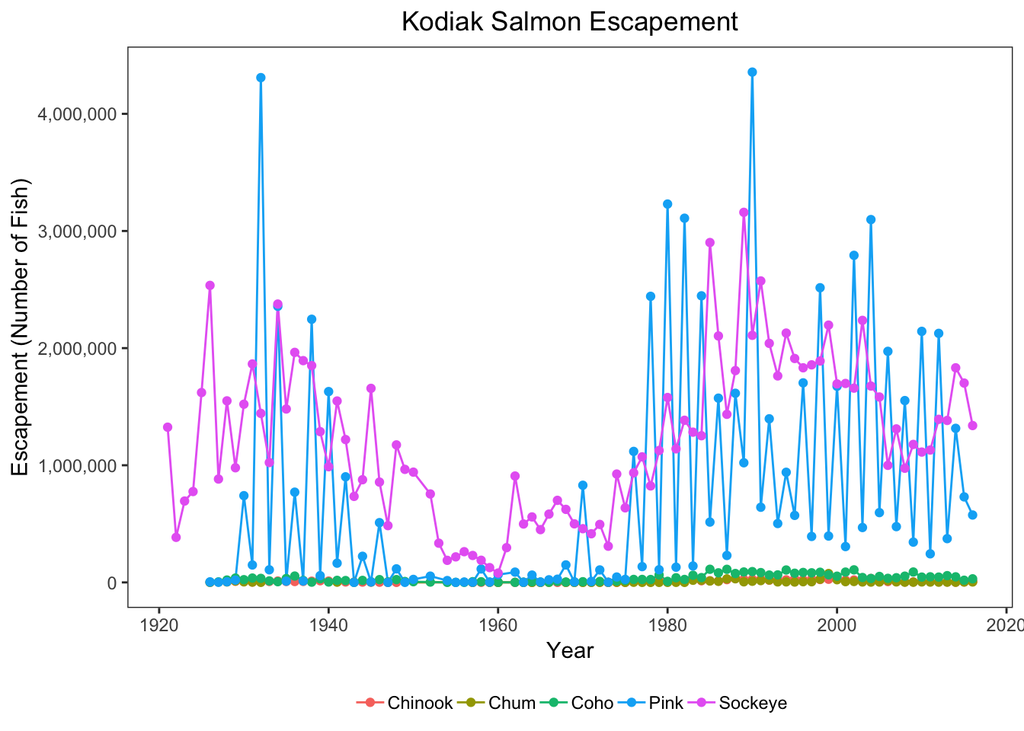

### We don’t want to have the y-axis values in scientific notation! This can be changed. you can add commas or a percent sent ex: scale_y_continuous(labels = percent)

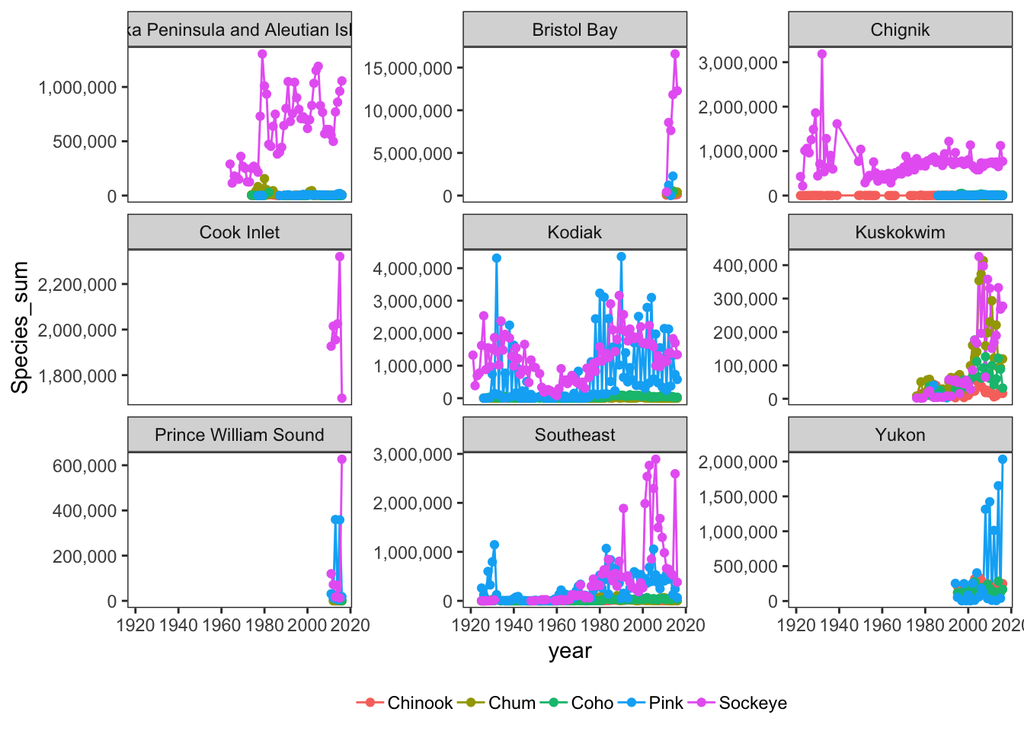

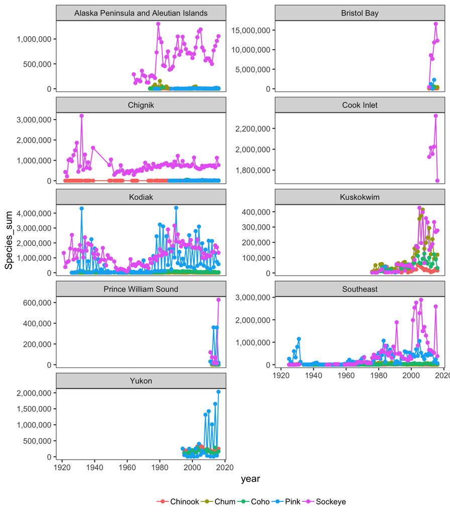

# Generate an interactive map

Map the sampling locations for escapement

- Find distinct lat/lon/location combinations

```r
locations <- esc %>%
  distinct(Location, Latitude, Longitude) %>%
  drop_na()

head(locations)
```

```
##         Location Latitude Longitude
## 1  Akalura Creek  57.1641 -154.2287
## 4    Anvik River  62.7000 -160.2000
## 6 Ayakulik River  57.1956 -154.5290
## 7     Bear Creek  56.0389 -160.2734
## 8     Bear River  56.0389 -160.2734
## 9  Big Bay Creek  58.5426 -152.5683
```

|  | Location | Latitude | Longitude |
| --- | --- | --- | --- |
| 1 | Akalura Creek | 57.1641 | -154.2287 |
| 4 | Anvik River | 62.7 | -160.2 |
| 6 | Ayakulik River | 57.1956 | -154.529 |
| 7 | Bear Creek | 56.0389 | -160.2734 |
| 8 | Bear River | 56.0389 | -160.2734 |
| 9 | Big Bay Creek | 58.5426 | -152.5683 |
| 10 | Big Kitoi Creek | 58.1915 | -152.3754 |
| 12 | Black Lake | 56.392 | -158.937 |
| 13 | Buskin River | 57.7768 | -152.5372 |
| 14 | Chelatna Lake | 62.4731 | -151.4545 |

[output cut: 58 more lines]

This creates the map!

```r
leaflet(locations) %>%
  addTiles() %>%
  addMarkers(lng = ~Longitude, lat = ~Latitude , popup = ~ Location)
```

[interactive chart not shown]